# Sprawozdanie 1

## Metoda łokciowa dla KNN

Sprawdza dokładność modelu w zależności od różnych `k`.  
Poniższy wykres wskazuje, że najwyższa dokładność występuje dla `k=3, 11, 21`. Wykres jednak nie pokazuje jednoznacznie, które z tych k jest najlepsze.

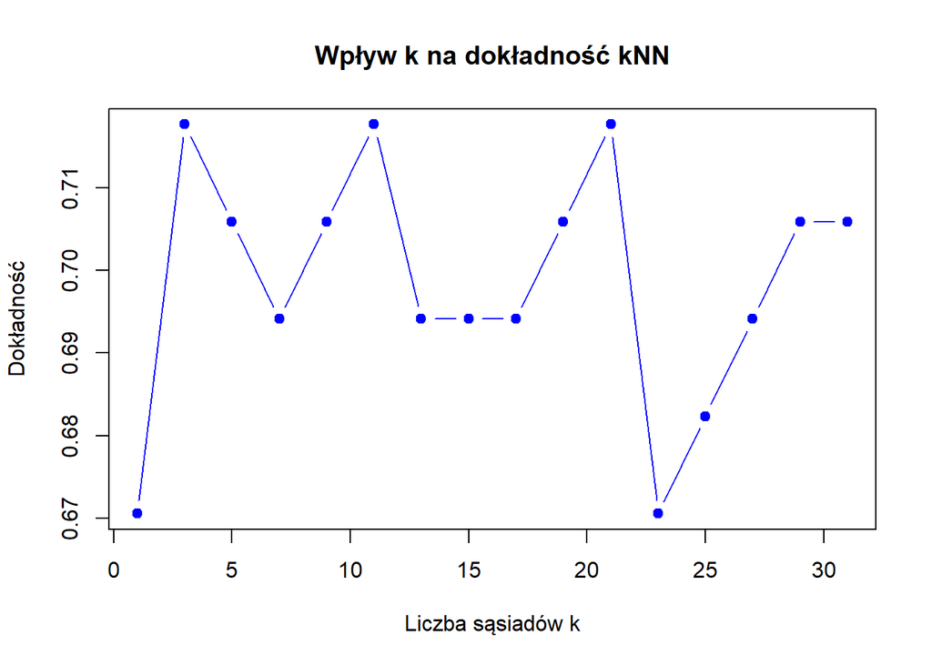

```r
#Które k wybrać
k_values <- seq(1, 31, 2)
accuracy <- numeric(length(k_values))
for(i in seq_along(k_values)){
  preds <- knn(cl = uczacy[, 11],
                train = uczacy[, -11],
                test = testowy[, -11],
                k = k_values[i])

  accuracy[i] <- mean(preds == testowy$stroke)
}
plot(k_values, accuracy, type = "b",
     xlab = "Liczba sąsiadów k",
     ylab = "Dokładność",
     main = "Wpływ k na dokładność kNN",
     col = "blue", pch = 19)
```

## Cross-validation dla KNN

Metoda cross-validation testuje różne k i wybiera najlepsze na podstawie średniej dokładności modelu.  
Wykres wyników otrzymanych metodą cross-validation wskazuje na to że w okolicach `k=9` lub `k=11` dalsze zwiększanie `k` nie poprawia znacząco dokładności modelu. Przyjęto zatem w modelu liczbę sąsiadów `k=11`, ponieważ oba testy wskazały na to, że jest to wartość dla której dokładność modelu jest najlepsza i zwiększenie liczby sąsiadów nie poprawi znacząco dokładności.

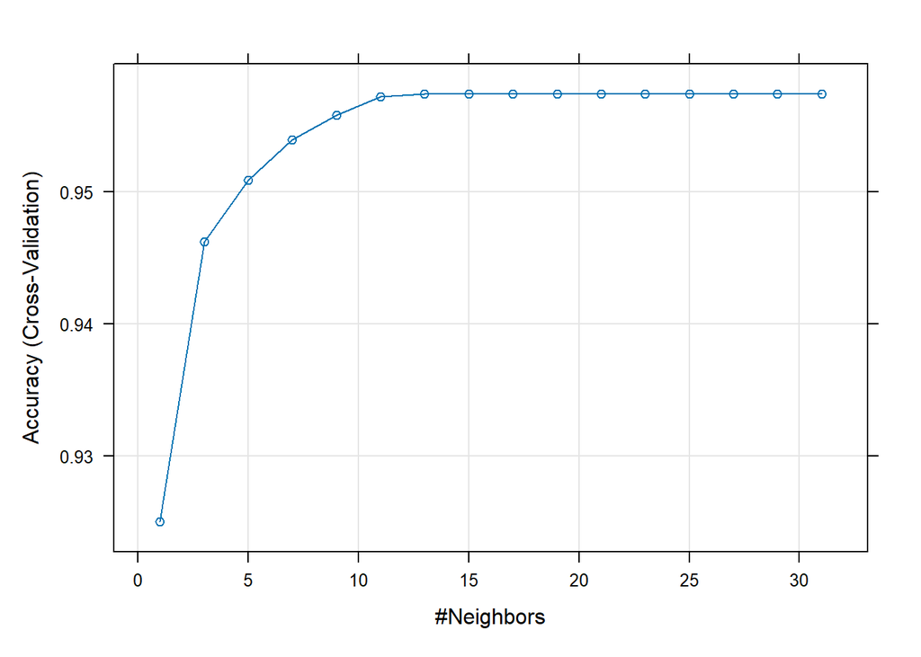

```r
#Cross-validation
set.seed(416669)
train_control = trainControl(method = "cv", number = 10)
k_grid = expand.grid(k = k_values)

knn_cv = train(
  x = dane_stroke[,-11],
  y = dane_stroke[,11],
  method = "knn",
  trControl = train_control,
  tuneGrid = k_grid
)

plot(knn_cv)
```

## Odpowiedzi na pytania z zadania 2

1. Jest to metoda, która przewiduje wartość zmiennej dla nowej obserwacji na podstawie najbliższych sąsiadów w zbiorze treningowym.
2. K w metodzie KNN oznacza ile najbliższych sąsiadów jest sprawdzanych przy klasyfikacji.  
   Nie ma jednoznacznej odpowiedzi jaka wartość k jest najlepsza, trzeba to sprawdzić za pomocą, np. sprawdzenia dla jakiej wartości k model ma największą dokładność.  
   Najlepiej kiedy k jest liczbą nieparzystą, ponieważ sprawia to, że nie ma remisów w klasyfikacji wartości zmiennej (np. gdy jest tyle samo najbliższych sąsiadów z obu grup). W przypadku remisu wartość zmiennej jest przypisywana losowo, co sprawia, że wyniki mogą być niedokładne.
3. Standaryzacja zazwyczaj jest wymagana, w szczególności gdy w modelu występują zmienne liczbowe, które mają różną skalę. Taka zmienna o dużej skali mogłaby zdominować obliczenia odległości.
4. Wielkość zbioru danych ma znaczenie dla KNN, ponieważ nie buduje modelu tylko przechowuje dane i liczby odległości podczas predykcji. Zatem większa liczba obserwacji może poprawić dokładność modelu, z uwagi na to, że model ma więcej informacji.
5. Zamiast klasyfikacji KNN może przewidywać wartości ciągłe. Wybierane jest k najbliższych punktów względem nowej obserwacji, a następnie liczona jest średnia wartość zmiennej celu tych sąsiadów.
6. W metodzie KNN można używać zmiennych kategorycznych, jednak jeśli to możliwe, to powinny być one kodowane binarnie (0/1). Gdy występuje więcej wartości jakościowych zmiennej, wtedy istotne jest, aby sensownie przypisywać im wartości liczbowe. Kiedy na przykład występują różne kolory w zmiennej “Kolor” nie ma sensu przypisywać im wartości 1-5, tylko trzeba podzielić je na tyle zmiennych binarnych ile jest kolorów.

# Zadanie 3

## Zastosowanie metody ważonej k-najbliższych sąsiadów (KKNN)

W metodzie KKNN z uwagi na dużą liczbę zmiennych binarnych, które są pomieszane z mniejszą liczba zmiennych liczbowych, odległości liczone były w metryce Manhattan.

```r
#Metoda kknn
k_vk = 9
# Predykcja na zbiorze uczącym
kknn.uczacy = kknn(formula = uczacy[, 11]~.,
                 train = uczacy[, -11],
                 test = uczacy[, -11],
                 k = k_vk,
                 distance = 1,
                 kernel = "rectangular")
kknn.uczacy.wyniki = fitted(kknn.uczacy)

#macierz błędów
table(kknn.uczacy.wyniki, uczacy$stroke)
```

```
##
## kknn.uczacy.wyniki   0   1
##                  0 118  34
##                  1  43 138
```

```r
# Prognoza na zbiorze testowym
kknn.testowy = kknn(formula = uczacy[, 11]~.,
                   train = uczacy[, -11],
                   test = testowy[, -11],
                   k = k_v,
                   distance = 1,
                   kernel = "rectangular")
kknn.testowy.wyniki = fitted(kknn.testowy)

#Macierz błędów z miarami jakości klasyfikacji
caret::confusionMatrix(kknn.testowy.wyniki, testowy$stroke, positive = "1")
```

```
## Confusion Matrix and Statistics
##
##           Reference
## Prediction  0  1
##          0 34  7
##          1 14 30
##
##                Accuracy : 0.7529
##                  95% CI : (0.6475, 0.8401)
##     No Information Rate : 0.5647
##     P-Value [Acc > NIR] : 0.0002472
##
##                   Kappa : 0.5081
##
##  Mcnemar's Test P-Value : 0.1904303
##
##             Sensitivity : 0.8108
##             Specificity : 0.7083
##          Pos Pred Value : 0.6818
##          Neg Pred Value : 0.8293
##              Prevalence : 0.4353
##          Detection Rate : 0.3529
##    Detection Prevalence : 0.5176
##       Balanced Accuracy : 0.7596
##
##        'Positive' Class : 1
##
```

## Metoda łokciowa dla KKNN

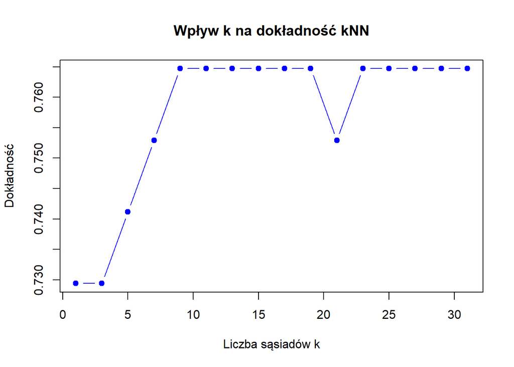

```r
#Które k wybrać dla kknn
for(i in seq_along(k_values)){
  model <- kknn(formula = uczacy[, 11] ~ .,
                train = uczacy[, -11],
                test = testowy[, -11],
                k = k_values[i],
                distance = 1)

  preds <- fitted(model)
  accuracy[i] <- mean(preds == testowy$stroke)
}
plot(k_values, accuracy, type = "b",
     xlab = "Liczba sąsiadów k",
     ylab = "Dokładność",
     main = "Wpływ k na dokładność kNN",
     col = "blue", pch = 19)
```

## Cross-Validation dla KKNN

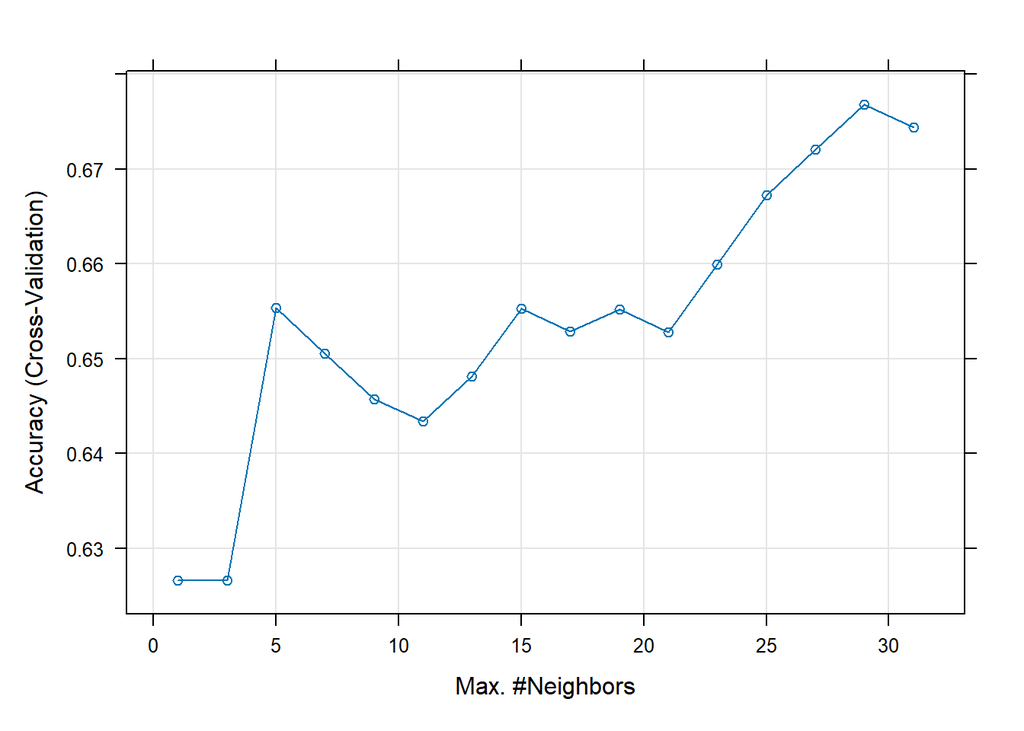

```r
k_values_kknn <- data.frame(kmax = k_values,
                       distance = 1,
                       kernel = "optimal")

kknn_cv <- train(
  stroke ~ .,
  data = dane_stroke_final,
  method = "kknn",
  trControl = train_control,
  tuneGrid = k_values_kknn
)

plot(kknn_cv)
```

## Odpowiedzi na pytania z zadania 3

1. W metodzie KKNN dodatkowo oprócz decyzji o klasyfikacji za pomocą większości głosów wśród k najbliższych sąsiadów, uwzględniane są wagi zależne od odległości ustalone przez funkcję Kernela. Powoduje to, że bliżsi sąsiedzi mają większy wpływ niż dalsi. Jest to zatem metoda bardziej elastyczna, która pozwala na więcej możliwości (dodatkowo wybór funkcji Kernela oraz metryki odległości).
2. Ograniczenia są podobne jak w przypadku metody KNN, funkcja Kernela może jednak nieco poprawić wyniki w przypadku dużego k.
3. Tak w metodzie KKNN wielkość zbioru ma znaczenie, ponieważ tak jak metoda KNN, jest to metoda leniwa, której wszystkie obliczenia są dokonywane przy predykcji.